Ullrich Köthe: **Fundamentals of Machine Learning**, Winter Semester 2018/19  
Notebook created by Jakob Kruse & Nicolas Roth & Nadia Alam

# Solutions for Exercise 1b

In order to run this notebook, you have to install the `pandas` package:  
`conda install pandas`

# 2 Asymptotic Error of the NN classifier for the Toy Example

We recall the toy example, where the feature variable $x\in \left[0 , 1\right]$ is real-valued and 1-dimensional and the response $y\in \left\{0 , 1\right\}$ is discrete with two classes. The prior probabilities and likelihoods are given by

$$p(y = 0) = p(y = 1) =1/2$$$$p(x\,|\,y = 0) = 2 - 2x$$$$p(x\,|\,y = 1) = 2x$$

We can easily compute the density of $x$ by marginalization over $y$

$$p(x) = p(x\,|\,y = 0)\,p(y = 0)+p(x\,|\,y = 1)\,p(y = 1) = (2 - 2x)\cdot 1/2 + 2x\cdot1/2 = 1$$

The posteriors are

$$p^*(y=0\,|\,x) = \frac{p(x\,|\,y = 0)\,p(y = 0)}{p(x)} = 1-x $$$$p^*(y=1\,|\,x) = \frac{p(x\,|\,y = 1)\,p(y = 1)}{p(x)} = x$$

The nearest-neighbor classiffier's asymptotic local error is given by the Gini impurity

$$p_{\infty}(\text{error}\,|\,x) = 1 - p^*(y=0\,|\,x)^2 - p^*(y=1\,|\,x)^2 = 1- (1 - x)^2 -x^2 = 2(x - x^2)$$

The asymptotic total error for the nearest neighbor classiffier for the toy example is the expectation of the local error over all $x$

$$p_{\infty}(\text{error}) = \int_0^1 p_{\infty}(\text{error}\,|\,x)\,p(x)\,dx = \int_0^1 2(x - x^2)\,dx= \frac{1}{3} = 33.33\%$$

You can use this theoretical result to interpret your experimental findings in exercise 1a. There the computed average error of the NN classifier with training sets of size 2 was 35%, i.e. pretty close to 33.33%. With training sets of size 100, it got even closer (almost exactly 33.33%) with lower standard deviation. An asymptotic total error of 33.33% suggests that the average error rate will converge against this value if we would calculate the average over the whole population.

# 3 Nearest Neighbor Classifcation on Real Data

## 3.1 Exploring the Data

```python
import numpy as np

import matplotlib.pyplot as plt
%matplotlib notebook

import pandas as pd
pd.options.display.float_format = '{:,.2f}'.format

from IPython.display import display
from sklearn import model_selection
from sklearn.neighbors import KNeighborsClassifier
from sklearn.datasets import load_digits
```

```
(1797, 64) float64
(1797, 8, 8) float64
(1797,) int64 [0 1 2 3 4 5 6 7 8 9 0 1 2 3 4 5 6 7 8 9]
(10,) int64 [0 1 2 3 4 5 6 7 8 9]
```

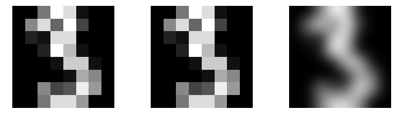

```python
# load digits data set
digits = load_digits()

data = digits["data"]
images = digits["images"]
target = digits["target"]
target_names = digits["target_names"]

print(data.shape, data.dtype)
print(images.shape, images.dtype)
print(target.shape, target.dtype, target[:20])
print(target_names.shape, target_names.dtype, target_names)

img = images[3,:,:]
assert 2 == len( img . shape )

fig = plt.figure(figsize = (10,3))
plt.gray()
plt.subplot('131'); plt.axis('off')
plt.imshow(img, interpolation = "nearest")
plt.subplot('132'); plt.axis('off')
plt.imshow(img, interpolation = "nearest")
plt.subplot('133'); plt.axis('off')
plt.imshow(img, interpolation = "bicubic")
fig.tight_layout(); plt.show()
```

The right-most image illustrates why we generally use `interpolation = 'nearest'`. For scientific analysis, it's important that we can see the exact value of each pixel in an image array, even if `interpolation = 'bicubic'` often yields visually more pleasing results.

```python
# split into train and test data
X_all = data
y_all = target
X_train, X_test, y_train , y_test = model_selection.train_test_split(
                                    digits.data,
                                    digits.target,
                                    test_size = 0.4,
                                    random_state = 0)
print(X_train.shape, X_test.shape)
print(y_train.shape, y_test.shape, y_train[:10])
```

```
(1078, 64) (719, 64)
(1078,) (719,) [6 5 3 0 2 9 7 7 4 0]
```

## 3.2 Distance function computation using loops

```python
# slow distance computation
def dist_loop(training, test):
    dist = np.zeros((training.shape[0], test.shape[0]), dtype = np.float64)
    for j in range(test.shape[0]):
        for i in range(training.shape[0]):
            dist[i,j] = np.sqrt(np.sum(np.square(training[i,:] - test[j,:])))
    return dist
```

```python
# measure time
%timeit dist_l = dist_loop(X_train, X_test)
dist_l = dist_loop(X_train, X_test)
```

```
5.66 s ± 180 ms per loop (mean ± std. dev. of 7 runs, 1 loop each)
```

## 3.3 Distance function computation using vectorization

The Euclidean distance between vectors $\textbf{a}, \textbf{b} \in \mathbb{R}^N$ is

\begin{align} \text{dist}(\textbf{a}, \textbf{b}) &= \sqrt{ (a_1 - b_1)^2 + (a_2 - b_2)^2 + \ldots }. \end{align}

In order to compute this for all $\textbf{a}$ that are rows of $\textbf{A}=$ `X_train` $\in \mathbb{R}^{I \times N}$ and all $\textbf{b}$ that are rows of $\textbf{B}=$ `X_test` $\in \mathbb{R}^{J \times N}$, we can contruct a big matrix $C \in \mathbb{R}^{I \times J \times N}$ containing all the differences $A_{i,n} - B_{j,n}$.

`numpy` has a useful feature called [broadcasting](https://docs.scipy.org/doc/numpy/user/basics.broadcasting.html) which helps us here. By adding a dimension to $\textbf{A}$ to be in $\mathbb{R}^{I \times 1 \times N}$, and $\textbf{B}$ to be in $\mathbb{R}^{1 \times J \times N}$ (both with `np.expand_dims()`), the matrices will automatically be replicated along the $1$-dimension to match each other's shapes when we subtract.

The resulting $I \times J \times N$ matrix can then be squared element-wise, summed up along the $N$-dimension, and the square root taken element-wise, which leaves us with the desired $I \times J$ distance matrix.

```python
# faster distance computation
def dist_vec(training, test):
    return np.sqrt(
        np.sum(
            np.square(
                np.expand_dims(training, axis = 1) - np.expand_dims(test, axis = 0)
            ),
            axis = 2
        )
    )
```

```python
# what does expand_dims do?
a = np.array([1, 2, 3, 4, 5])
b = np.array([10, 20])
print(a.shape, b.shape)
print(b, '\n')

a = np.expand_dims(a, axis = 0)
b = np.expand_dims(b, axis = 1)
print(a.shape, b.shape)
print(b, '\n')

# element-wise operations in numpy can then use broadcasting!
print(a + b)
```

```
(5,) (2,)
[10 20]

(1, 5) (2, 1)
[[10]
 [20]]

[[11 12 13 14 15]
 [21 22 23 24 25]]
```

```python
# measure time
%timeit dist_v = dist_vec(X_train, X_test)
dist_v = dist_vec(X_train, X_test)
```

```
409 ms ± 30.7 ms per loop (mean ± std. dev. of 7 runs, 1 loop each)
```

```python
print('Loop-based and vectorized give same results:', np.array_equal(dist_v, dist_l))
```

```
Loop-based and vectorized give same results: False
```

```python
np.max(abs(dist_v - dist_l))
```

```
1.4210854715202004e-14
```

Though they are not absolutely equal the maximum value of the difference show the differences are negligible.

#### Alternative vectorized approach

Alternatively, the Euclidean distance between vectors $\textbf{a}, \textbf{b} \in \mathbb{R}^N$ can be transformed as follows:

\begin{align} \text{dist}(\textbf{a}, \textbf{b}) &= \sqrt{ (a_1 - b_1)^2 + (a_2 - b_2)^2 + \ldots } \\ &= \sqrt{ (a_1^2 + a_2^2 + \ldots) + (b_1^2 + b_2^2 + \ldots) - (2 a_1 b_1 + 2 a_2 b_2 + \ldots) } \\ &= \sqrt{ \sum_i a_i^2 + \sum_i b_i^2 - 2 \cdot \textbf{a}^\top \cdot \textbf{b} } \\ \end{align}

This computation can also be performed for many vectors at once by operating on matrices $\textbf{A} \in \mathbb{R}^{I \times N}$ and $\textbf{B} \in \mathbb{R}^{J \times N}$, which contain the $\textbf{a}$s and $\textbf{b}$s as rows. This method turns out to be considerably faster, since the largest constructed matrix is of size $I \times J$, as opposed to the $I \times J \times N$-matrix we constructed in the previous vectorized method.

```python
def dist_vec_alternative(training, test):
    AB = np.dot(test, np.transpose(training)) # shape is (n_test, n_train)
    AA = np.sum(np.square(test), axis = 1) # shape is (n_test,)
    BB = np.sum(np.square(training), axis = 1) # shape is (n_train,)

    dist_matrix = np.sqrt(np.transpose(BB - 2 * AB) + AA) # shape is (n_train, n_test)

    return dist_matrix
```

```python
# measure time
%timeit dist_va = dist_vec_alternative(X_train, X_test)
dist_va = dist_vec_alternative(X_train, X_test)
```

```
13.7 ms ± 583 µs per loop (mean ± std. dev. of 7 runs, 100 loops each)
```

```python
print('Loop-based and alternative vectorized give same results:', np.array_equal(dist_va, dist_l))
```

```
Loop-based and alternative vectorized give same results: False
```

```python
np.max(abs(dist_va - dist_l))
```

```
1.4210854715202004e-14
```

Similarly we get negligible differences.

## 3.4 Implement the k-nearest neighbour classifer

```python
# k-nearest-neighbor classifier based on vectorized distance computation
def k_nearest_neighbors(X_train, y_train, X_test, k):
    # find k nearest neighbors for each test image
    dist = dist_vec_alternative(X_train, X_test)
    indices = np.argsort(dist, axis = 0)[:k,:] # 2D array containing indices of k neighbors with lowest distance
    neighbors = y_train[indices] # indexing y_train (1D) with indices (2D) gives 2D array of neighbors' classes!

    # find most common class among neighbors of each test image
    # (you could also use np.bincount() or scipy.stats.mode() for the voting)
    counts = np.zeros((10, X_test.shape[0]))
    for i in range(k):
        for j in range(X_test.shape[0]):
            counts[neighbors[i,j], j] += 1

    return np.argmax(counts, axis = 0)
```

```python
# what does argsort do?
a = np.array([2, 4, 1, 7, 8])
indices = np.argsort(a)
print(indices)
print('-->', a[indices], '\n')

b = np.array(
    [[2, 4, 1, 7, 8],
     [6, 0, 3, 2, 6]])
print(np.argsort(b, axis = 1))
```

```
[2 0 1 3 4]
--> [1 2 4 7 8]

[[2 0 1 3 4]
 [1 3 2 0 4]]
```

```python
# use KNN classifier to distinguish two classes
def knn_compare(classA, classB, k):
    X_train_AB = X_train[np.logical_or(classA == y_train, classB == y_train)]
    y_train_AB = y_train[np.logical_or(classA == y_train, classB == y_train)]

    X_test_AB = X_test[np.logical_or(classA == y_test, classB == y_test)]
    y_test_AB = y_test[np.logical_or(classA == y_test, classB == y_test)]

    result = k_nearest_neighbors(X_train_AB, y_train_AB, X_test_AB, k)

    return 100 * (1 - np.count_nonzero(result == y_test_AB) / len(result))
```

### Why no loops?

As our distance matrix example showed, loops are often very inefficient in a scripting language such as Python. The comparison and indexing functionality of `numpy`, however, uses highly optimized code and will generally have better performance. If you can express an operation in `numpy`-instructions without sacrificing too much readability, do it!

```python
%timeit X_train_AB = X_train[np.logical_or(3 == y_train, 9 == y_train)]
```

```
25.5 µs ± 362 ns per loop (mean ± std. dev. of 7 runs, 10000 loops each)
```

```python
%%timeit
filtered_data = []
for i in range(len(y_train)):
    if (y_train[i]==3) or (y_train[i]==9):
        filtered_data.append(X_train[i])
```

```
637 µs ± 20.4 µs per loop (mean ± std. dev. of 7 runs, 1000 loops each)
```

```python
# compute 'confusion' matrix for all pairs of classes and all values k
## Note: only pair (3,9) is enough for the exercise
confusion = np.zeros((6,10,10))
ks = [1, 3, 5, 9, 17, 33]
for k in range(6):
    for i in range(10):
        for j in range(10):
            confusion[k,i,j] = knn_compare(i,j,ks[k])
```

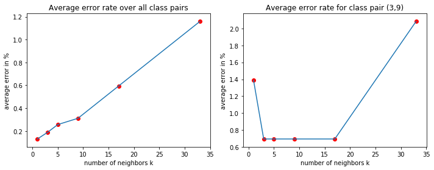

```python
# plot average error rate for each k
fig = plt.figure(figsize = (10, 4))
# for all pairs of classes
plt.subplot('121'); plt.title('Average error rate over all class pairs')
plt.plot(ks, confusion.mean(axis = 2).mean(axis = 1))
plt.scatter(ks, confusion.mean(axis = 2).mean(axis = 1),c='Red')
plt.ylabel('average error in %'); plt.xlabel('number of neighbors k')
# for class pair (3,9)
plt.subplot('122'); plt.title('Average error rate for class pair (3,9)')
plt.plot(ks, confusion[:,3,9])
plt.scatter(ks, confusion[:,3,9],c='Red')
plt.ylabel('average error in %'); plt.xlabel('number of neighbors k')

fig.tight_layout(); plt.show()
```

The sweet spot for $k$ depends on the specific class pair in this data set. Overall though, we can see that $k=1$ has the lowest error rate.

Further reading: [Choice of Neighbor Order in Nearest-Neighbor Classification](https://arxiv.org/pdf/0810.5276.pdf)

```python
# display values for one k as Pandas DataFrame
# say for k=33 which is ks[5]
i = 5
# display as Pandas DataFrame
def fade_zeros(s):
    return ['color: lightgray' if (v == 0) else 'color: black' for v in s]

display(
    pd.DataFrame(data = confusion[i,:,:], index = target_names, columns = target_names)
    .rename_axis('k = ' + str(ks[i]), axis = 'columns')
    .style.apply(fade_zeros)
    .format('{0:.2f}%')
)
```

| k = 33 | 0 | 1 | 2 | 3 | 4 | 5 | 6 | 7 | 8 | 9 |
| --- | --- | --- | --- | --- | --- | --- | --- | --- | --- | --- |
| 0 | 0.00% | 0.00% | 0.76% | 0.00% | 0.00% | 0.00% | 0.74% | 0.00% | 0.72% | 0.75% |
| 1 | 0.00% | 0.00% | 10.42% | 0.00% | 0.74% | 0.00% | 2.68% | 0.00% | 3.97% | 0.68% |
| 2 | 0.76% | 10.42% | 0.00% | 2.13% | 2.24% | 0.00% | 0.00% | 2.21% | 2.01% | 0.69% |
| 3 | 0.00% | 0.00% | 2.13% | 0.00% | 0.75% | 0.63% | 0.00% | 2.22% | 3.38% | 2.08% |
| 4 | 0.00% | 0.74% | 2.24% | 0.75% | 0.00% | 1.32% | 0.00% | 1.56% | 1.42% | 0.73% |
| 5 | 0.00% | 0.00% | 0.00% | 0.63% | 1.32% | 0.00% | 1.21% | 0.00% | 0.00% | 3.07% |
| 6 | 0.74% | 2.68% | 0.00% | 0.00% | 0.00% | 1.21% | 0.00% | 0.00% | 1.30% | 0.00% |
| 7 | 0.00% | 0.00% | 2.21% | 2.22% | 1.56% | 0.00% | 0.00% | 0.00% | 0.70% | 2.88% |
| 8 | 0.72% | 3.97% | 2.01% | 3.38% | 1.42% | 0.00% | 1.30% | 0.70% | 0.00% | 3.95% |
| 9 | 0.75% | 0.68% | 0.69% | 2.08% | 0.73% | 3.07% | 0.00% | 2.88% | 3.95% | 0.00% |

```python
# similarly for k=1 which is ks[0]
i = 0
# display as Pandas DataFrame
def fade_zeros(s):
    return ['color: lightgray' if (v == 0) else 'color: black' for v in s]

display(
    pd.DataFrame(data = confusion[i,:,:], index = target_names, columns = target_names)
    .rename_axis('k = ' + str(ks[i]), axis = 'columns')
    .style.apply(fade_zeros)
    .format('{0:.2f}%')
)
```

| k = 1 | 0 | 1 | 2 | 3 | 4 | 5 | 6 | 7 | 8 | 9 |
| --- | --- | --- | --- | --- | --- | --- | --- | --- | --- | --- |
| 0 | 0.00% | 0.00% | 0.00% | 0.00% | 0.00% | 0.00% | 0.00% | 0.00% | 0.00% | 0.00% |
| 1 | 0.00% | 0.00% | 0.00% | 0.00% | 0.00% | 0.00% | 0.00% | 0.00% | 1.32% | 0.00% |
| 2 | 0.00% | 0.00% | 0.00% | 0.00% | 0.00% | 0.00% | 0.00% | 0.00% | 0.00% | 0.00% |
| 3 | 0.00% | 0.00% | 0.00% | 0.00% | 0.00% | 0.63% | 0.00% | 0.00% | 0.68% | 1.39% |
| 4 | 0.00% | 0.00% | 0.00% | 0.00% | 0.00% | 0.00% | 0.00% | 0.00% | 0.00% | 0.00% |
| 5 | 0.00% | 0.00% | 0.00% | 0.63% | 0.00% | 0.00% | 0.61% | 0.00% | 0.00% | 1.23% |
| 6 | 0.00% | 0.00% | 0.00% | 0.00% | 0.00% | 0.61% | 0.00% | 0.00% | 0.00% | 0.00% |
| 7 | 0.00% | 0.00% | 0.00% | 0.00% | 0.00% | 0.00% | 0.00% | 0.00% | 0.00% | 0.00% |
| 8 | 0.00% | 1.32% | 0.00% | 0.68% | 0.00% | 0.00% | 0.00% | 0.00% | 0.00% | 0.66% |
| 9 | 0.00% | 0.00% | 0.00% | 1.39% | 0.00% | 1.23% | 0.00% | 0.00% | 0.66% | 0.00% |

# 4 Cross-validation

```python
def cross_validate(n_folds, k = 1, shuffle = True, n_repetitions = 20):
    sklearn_knn = KNeighborsClassifier(n_neighbors = k)

    results = []
    for i in range(n_repetitions if shuffle else 1):
        error_rates_own = []; error_rates_sklearn = []

        # (shuffle and) split up the data
        if shuffle: perm = np.random.permutation(range(len(y_all)))
        else:       perm = range(len(y_all))
        X_folds = np.array_split(X_all[perm], n_folds)
        y_folds = np.array_split(y_all[perm], n_folds)

        for n in range(n_folds):
            # construct train and test set from folds
            X_train_f = np.concatenate([X_folds[i] for i in range(n_folds) if i != n])
            X_test_f = X_folds[n]
            y_train_f = np.concatenate([y_folds[i] for i in range(n_folds) if i != n])
            y_test_f = y_folds[n]

            # run our own nearest neighbor classifier
            result_own = k_nearest_neighbors(X_train_f, y_train_f, X_test_f, k)
            error_rates_own.append(100 * (1 - np.count_nonzero(result_own == y_test_f) / len(result_own)))

            # run sklearn's nearest neighbor classifier
            sklearn_knn.fit(X_train_f, y_train_f)
            result_sklearn = sklearn_knn.predict(X_test_f)
            error_rates_sklearn.append(100 * (1 - np.count_nonzero(result_sklearn == y_test_f) / len(result_sklearn)))

        results.append(np.array(
                [[np.mean(error_rates_own), np.std(error_rates_own)],
                 [np.mean(error_rates_sklearn), np.std(error_rates_sklearn)]]
            ))

    return np.mean(np.concatenate(results), axis = 0)
```

```python
# run experiments for say k=5
n_folds = [2,5,10]
values = np.zeros((2,2,3,2)) # shuffle, classifier, n, results

for shuffle in [False, True]:
    for n in range(len(n_folds)):
        values[int(shuffle), :, n, :] = cross_validate(n_folds[n], k=5, shuffle = shuffle)
```

```python
# display as Pandas DataFrames
display(pd.DataFrame(
    data = np.hstack([values[0,0,:,:], values[1,0,:,:]]),
    index = ['n = 2', 'n = 5', 'n = 10'],
    columns = ['error rate (straight)', 'stddev (straight)', 'error rate (shuffled)', 'stddev (shuffled)'])
    .rename_axis('OWN', axis = 'columns')
    .style.format('{0:.3f} %')
)
display(pd.DataFrame(
    data = np.hstack([values[0,1,:,:], values[1,1,:,:]]),
    index = ['n = 2', 'n = 5', 'n = 10'],
    columns = ['error rate (straight)', 'stddev (straight)', 'error rate (shuffled)', 'stddev (shuffled)'])
    .rename_axis('SKlearn', axis = 'columns')
    .style.format('{0:.3f} %')
)
```

| OWN | error rate (straight) | stddev (straight) | error rate (shuffled) | stddev (shuffled) |
| --- | --- | --- | --- | --- |
| n = 2 | 4.786 % | 0.331 % | 2.009 % | 0.261 % |
| n = 5 | 3.561 % | 0.967 % | 1.484 % | 0.590 % |
| n = 10 | 2.587 % | 1.853 % | 1.286 % | 0.749 % |

| SKlearn | error rate (straight) | stddev (straight) | error rate (shuffled) | stddev (shuffled) |
| --- | --- | --- | --- | --- |
| n = 2 | 4.786 % | 0.331 % | 2.009 % | 0.261 % |
| n = 5 | 3.561 % | 0.967 % | 1.484 % | 0.590 % |
| n = 10 | 2.587 % | 1.853 % | 1.286 % | 0.749 % |

The two classifiers seem to yield identical results.

When using more folds, the training set gets larger. This causes the error rate to decrease.

But using more folds also means that we evaluate the models on a greater number of different (and smaller) test sets. This causes the variance to increase.

Shuffling the data prior to creating folds significantly decreases the average error in all configurations. This suggests that the data set is ordered in such a way that different sections have different characteristics. A likely explanation is that the digits might be arranged by author, and the NN classifier generalizes worse to handwriting styles not present in the training data.